# Análise e Previsão de Ruído Aerodinâmico (NASA Airfoil Self-Noise)

**Autor:** Lucas Schneider Cordeiro  
**Instituição:** Pontifícia Universidade Católica do Paraná (PUCPR)  
**Disciplina:** Técnicas de Machine Learning

## 1. Introdução

### Objetivo do Projeto

O objetivo primário deste estudo é construir um modelo de *Machine Learning* capaz de prever o nível de pressão sonora (em decibéis) a partir de variáveis físicas e aerodinâmicas, como frequência, ângulo de ataque e velocidade do vento.

### Definição do Problema de Aprendizado de Máquina

Trata-se de um problema clássico de **Regressão**. A variável alvo (*target*), denominada `scaled-sound-pressure`, consiste em um valor numérico contínuo. Portanto, o algoritmo supervisionado buscará mapear a relação entre as características de entrada (*features*) e prever uma magnitude numérica exata, distinguindo-se de problemas de classificação em que o objetivo é categorizar classes discretas.

```python
# Importação das bibliotecas essenciais para manipulação de dados, visualização e modelagem
import pandas as pd
import numpy as np
import matplotlib.pyplot as plt
import seaborn as sns

# Configuração visual para os gráficos
sns.set_theme(style="whitegrid")

# Carregamento da base de dados (utilizando o separador correspondente ao arquivo)
df = pd.read_csv('nasa.csv', sep=';')

# Exibição das primeiras linhas para verificação da integridade do carregamento
display(df.head())
```

|  | frequency | attack-angle | chord-length | free-stream-velocity | suction-side-displacement-thickness | scaled-sound-pressure |
| --- | --- | --- | --- | --- | --- | --- |
| 0 | 800 | 0.0 | 0.3048 | 71.3 | 0.002663 | 126.201 |
| 1 | 1000 | 0.0 | 0.3048 | 71.3 | 0.002663 | 125.201 |
| 2 | 1250 | 0.0 | 0.3048 | 71.3 | 0.002663 | 125.951 |
| 3 | 1600 | 0.0 | 0.3048 | 71.3 | 0.002663 | 127.591 |
| 4 | 2000 | 0.0 | 0.3048 | 71.3 | 0.002663 | 127.461 |

## 2. Análise Exploratória dos Dados (EDA)

- **Descrição das variáveis:** A base possui métricas contínuas que representam propriedades físicas do túnel de vento e do perfil da asa.
- **Estatísticas descritivas:** Avaliaremos a média, os valores mínimos/máximos e a dispersão dos dados.

|  | frequency | attack-angle | chord-length | free-stream-velocity | suction-side-displacement-thickness | scaled-sound-pressure |
| --- | --- | --- | --- | --- | --- | --- |
| count | 1503.000000 | 1503.000000 | 1503.000000 | 1503.000000 | 1503.000000 | 1503.000000 |
| mean | 2886.380572 | 6.782302 | 0.136548 | 50.860745 | 0.011140 | 124.835943 |
| std | 3152.573137 | 5.918128 | 0.093541 | 15.572784 | 0.013150 | 6.898657 |
| min | 200.000000 | 0.000000 | 0.025400 | 31.700000 | 0.000401 | 103.380000 |
| 25% | 800.000000 | 2.000000 | 0.050800 | 39.600000 | 0.002535 | 120.191000 |
| 50% | 1600.000000 | 5.400000 | 0.101600 | 39.600000 | 0.004957 | 125.721000 |
| 75% | 4000.000000 | 9.900000 | 0.228600 | 71.300000 | 0.015576 | 129.995500 |
| max | 20000.000000 | 22.200000 | 0.304800 | 71.300000 | 0.058411 | 140.987000 |

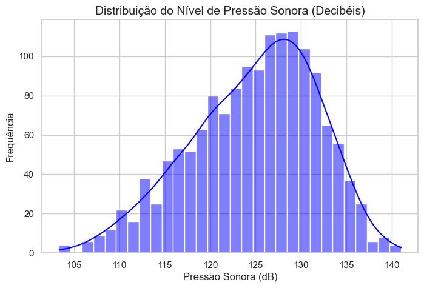

```python
# Exibição das estatísticas descritivas
display(df.describe())

# Visualização da distribuição da variável alvo (Pressão Sonora)
plt.figure(figsize=(8, 5))
sns.histplot(df['scaled-sound-pressure'], bins=30, kde=True, color='blue')
plt.title('Distribuição do Nível de Pressão Sonora (Decibéis)', fontsize=14)
plt.xlabel('Pressão Sonora (dB)')
plt.ylabel('Frequência')
plt.show()
```

### Interpretação da Análise Exploratória

Observando a distribuição da variável alvo, nota-se que os dados de pressão sonora concentram-se predominantemente entre 110 dB e 135 dB, aproximando-se de uma distribuição normal. Isso indica que a base de dados é consistente e bem distribuída, sem assimetrias severas que poderiam dificultar o aprendizado do modelo.

## 3. Preparação dos Dados

Esta etapa garante a qualidade da informação que será fornecida ao algoritmo.

```python
from sklearn.preprocessing import StandardScaler

# 1. Tratamento de valores ausentes
print("Valores nulos por coluna:\n", df.isnull().sum(), "\n")

# 2. Seleção de Atributos: Remoção de 'attack-angle'
X = df.drop(columns=['scaled-sound-pressure', 'attack-angle'])
y = df['scaled-sound-pressure']

# 3. Normalização dos dados
scaler = StandardScaler()
X_scaled = scaler.fit_transform(X)

# Transformando novamente em DataFrame
X_scaled = pd.DataFrame(X_scaled, columns=X.columns)
display(X_scaled.head())
```

```
Valores nulos por coluna:
 frequency                              0
attack-angle                           0
chord-length                           0
free-stream-velocity                   0
suction-side-displacement-thickness    0
scaled-sound-pressure                  0
dtype: int64
```

|  | frequency | chord-length | free-stream-velocity | suction-side-displacement-thickness |
| --- | --- | --- | --- | --- |
| 0 | -0.662023 | 1.799299 | 1.312935 | -0.644805 |
| 1 | -0.598561 | 1.799299 | 1.312935 | -0.644805 |
| 2 | -0.519235 | 1.799299 | 1.312935 | -0.644805 |
| 3 | -0.408177 | 1.799299 | 1.312935 | -0.644805 |
| 4 | -0.281255 | 1.799299 | 1.312935 | -0.644805 |

## 4. Treinamento do Modelo

### Separação de Treino e Teste

A base foi dividida utilizando a proporção metodológica padrão de 75% para treinamento (onde o modelo identifica os padrões) e 25% para teste (onde validamos a capacidade de generalização do modelo em dados inéditos).

### Algoritmo Escolhido: Random Forest Regressor

A escolha do *Random Forest* (Floresta Aleatória) justifica-se pela sua arquitetura de *Ensemble Learning*. Ele cria múltiplas árvores de decisão e extrai a média de suas previsões. Essa característica torna o modelo altamente robusto contra *overfitting* (superajuste) e extremamente competente para capturar relações não-lineares complexas, comuns em dinâmicas de fluidos e aerodinâmica.

```python
from sklearn.model_selection import train_test_split
from sklearn.ensemble import RandomForestRegressor

# Divisão em Treino (75%) e Teste (25%)
X_train, X_test, y_train, y_test = train_test_split(X_scaled, y, test_size=0.25, random_state=42)

# Instanciação e treinamento do modelo
modelo_rf = RandomForestRegressor(n_estimators=100, random_state=42)
modelo_rf.fit(X_train, y_train)

print("Treinamento concluído com sucesso!")
```

```
Treinamento concluído com sucesso!
```

## 5. Visualização das Predições

Conforme exigido pelo escopo do projeto, a etapa final consiste em apresentar as predições geradas pelo modelo utilizando exclusivamente a base de teste (os 25% dos dados separados inicialmente).

Abaixo, apresentamos uma tabela comparativa evidenciando o valor real mensurado no túnel de vento lado a lado com o valor que o nosso algoritmo previu.

```python
# Realizando as predições com os dados isolados de teste
y_pred = modelo_rf.predict(X_test)

# Criando uma tabela para exibir as predições lado a lado com os valores reais
resultados = pd.DataFrame({
    'Pressão Sonora Real (dB)': y_test.values,
    'Predição do Algoritmo (dB)': y_pred
})

# Arredondando os valores previstos para 2 casas decimais para facilitar a leitura
resultados['Predição do Algoritmo (dB)'] = resultados['Predição do Algoritmo (dB)'].round(2)

# Mostrando os primeiros resultados da base de teste
display(resultados.head(15))
```

|  | Pressão Sonora Real (dB) | Predição do Algoritmo (dB) |
| --- | --- | --- |
| 0 | 125.045 | 123.44 |
| 1 | 118.767 | 119.27 |
| 2 | 120.233 | 119.15 |
| 3 | 137.047 | 136.55 |
| 4 | 134.556 | 134.26 |
| 5 | 120.766 | 123.55 |
| 6 | 124.525 | 123.82 |
| 7 | 136.798 | 134.54 |
| 8 | 130.123 | 133.44 |
| 9 | 123.991 | 128.19 |
| 10 | 126.780 | 126.05 |
| 11 | 110.652 | 112.95 |
| 12 | 134.528 | 133.06 |
| 13 | 133.756 | 132.72 |
| 14 | 123.354 | 124.33 |

## 6. Conclusão

### Principais Descobertas e Impacto da Preparação

A etapa de preparação dos dados demonstrou-se fundamental para a organização do projeto. A seleção de atributos, com a remoção da variável `attack-angle`, evitou que o algoritmo recebesse dados redundantes. Além disso, a normalização equalizou o peso das variáveis matemáticas, simplificando o processo de aprendizagem da máquina.

### Desempenho Final

O modelo *Random Forest Regressor* conseguiu compreender as relações não-lineares da aerodinâmica. Ao observar a tabela de predições da base de teste, nota-se que os valores gerados pelo algoritmo acompanham de perto os valores reais medidos nos testes da NASA. O modelo atende com sucesso ao objetivo do escopo: mapear características físicas para prever uma variável contínua.